# Baltimore Religious Buildings

Nana-Ama

May 6, 2017

## Injesting Baltimore City Data: Baltimore Religious Buildings

This project studies Baltimore City data provided by its local government on www.data.baltimorecity.gov. The purpose of this assignment is to learn how to import a chosen data set and plot its data. The data set I have chosen is the record of Baltimore’s religious buildings. Using R packages, ggplot2 and ggmap, I am able to plot the buildings on a map of Baltimore. The map is map in order to see the spread of all 513 buildings throughout the entire city.

```r
source ("C:/Users/Tess/Downloads/Homework-2/RL.R")
#Religious_Buildings <-read_csv("C:/Users/Tess/Downloads/Religious_Buildings.csv)
#View(Religious_Buildings)
#This is the code in the sourced R script sourced file.
library(readr)
library (knitr)
head (Religious_Buildings)
```

```
## # A tibble: 6 × 7
##                               name   type zipCode
##                              <chr>  <chr>   <int>
## 1        Christian Memorial Church Church   21217
## 2       Har Sinai Church Of Christ Church   21231
## 3                     Lords Church Church   21215
## 4  Hallelujah United Church Of God Church   21215
## 5 Fourth Mount Zion Baptist Church Church   21216
## 6         Church Of The Living God Church   21223
## # ... with 4 more variables: neighborhood <chr>, councilDistrict <int>,
## #   policeDistrict <chr>, `Location 1` <chr>
```

The code chunk above identifies the Religious Buildings data set. It also heads the first six lines and identifies the variables within it.

## Creating a map of Baltimore’s Religious Buildings

[output not shown]

[output not shown]

[output not shown]

[output not shown]

[output not shown]

[output not shown]

[output not shown]

[output not shown]

[output not shown]

[output not shown]

[output not shown]

[output not shown]

[output not shown]

[output not shown]

[output not shown]

[output not shown]

[output not shown]

[output not shown]

[output not shown]

[output not shown]

[output not shown]

[output not shown]

[output not shown]

[output not shown]

[output not shown]

[output not shown]

[output not shown]

[output not shown]

[output not shown]

[output not shown]

[output not shown]

[output not shown]

[output not shown]

[output not shown]

[output not shown]

[output not shown]

[output not shown]

[output not shown]

[output not shown]

[output not shown]

[output not shown]

[output not shown]

[output not shown]

[output not shown]

[output not shown]

[output not shown]

[output not shown]

[output not shown]

[output not shown]

[output not shown]

[output not shown]

[output not shown]

[output not shown]

[output not shown]

[output not shown]

[output not shown]

[output not shown]

[output not shown]

[output not shown]

[output not shown]

[output not shown]

[output not shown]

[output not shown]

[output not shown]

[output not shown]

[output not shown]

[output not shown]

[output not shown]

[output not shown]

[output not shown]

[output not shown]

[output not shown]

[output not shown]

[output not shown]

[output not shown]

[output not shown]

[output not shown]

[output not shown]

[output not shown]

[output not shown]

[output not shown]

[output not shown]

[output not shown]

[output not shown]

[output not shown]

[output not shown]

[output not shown]

[output not shown]

[output not shown]

[output not shown]

[output not shown]

[output not shown]

[output not shown]

[output not shown]

[output not shown]

[output not shown]

[output not shown]

[output not shown]

[output not shown]

[output not shown]

[output not shown]

[output not shown]

[output not shown]

[output not shown]

[output not shown]

[output not shown]

[output not shown]

[output not shown]

[output not shown]

[output not shown]

[output not shown]

[output not shown]

[output not shown]

[output not shown]

[output not shown]

[output not shown]

[output not shown]

[output not shown]

[output not shown]

[output not shown]

[output not shown]

[output not shown]

[output not shown]

[output not shown]

[output not shown]

[output not shown]

[output not shown]

[output not shown]

[output not shown]

[output not shown]

[output not shown]

[output not shown]

[output not shown]

[output not shown]

[output not shown]

[output not shown]

[output not shown]

[output not shown]

[output not shown]

[output not shown]

[output not shown]

[output not shown]

[output not shown]

[output not shown]

[output not shown]

[output not shown]

[output not shown]

[output not shown]

[output not shown]

[output not shown]

[output not shown]

[output not shown]

[output not shown]

[output not shown]

[output not shown]

[output not shown]

[output not shown]

[output not shown]

[output not shown]

[output not shown]

[output not shown]

[output not shown]

[output not shown]

[output not shown]

[output not shown]

[output not shown]

[output not shown]

[output not shown]

[output not shown]

[output not shown]

[output not shown]

[output not shown]

[output not shown]

[output not shown]

[output not shown]

[output not shown]

[output not shown]

[output not shown]

[output not shown]

[output not shown]

[output not shown]

[output not shown]

[output not shown]

[output not shown]

[output not shown]

[output not shown]

[output not shown]

[output not shown]

[output not shown]

[output not shown]

[output not shown]

[output not shown]

[output not shown]

[output not shown]

[output not shown]

[output not shown]

[output not shown]

[output not shown]

[output not shown]

[output not shown]

[output not shown]

[output not shown]

[output not shown]

[output not shown]

[output not shown]

[output not shown]

[output not shown]

```r
#library (ggmap)
#library(ggplot2)
#df <-geocode(Religious_Buildings$`Location 1`): code to pull coordinates
```

In order to create a map of the buildings using ggmap and ggplot2, the geographic coordinates of the various locations are required. This code creates a data frame of the coordinates to be plotted on top of a map of Baltimore which is generated all through ggmap.

[figure not shown]

```
##         lon      lat
## 1 -76.61219 39.29038
```

```
## Using zoom = 12...
```

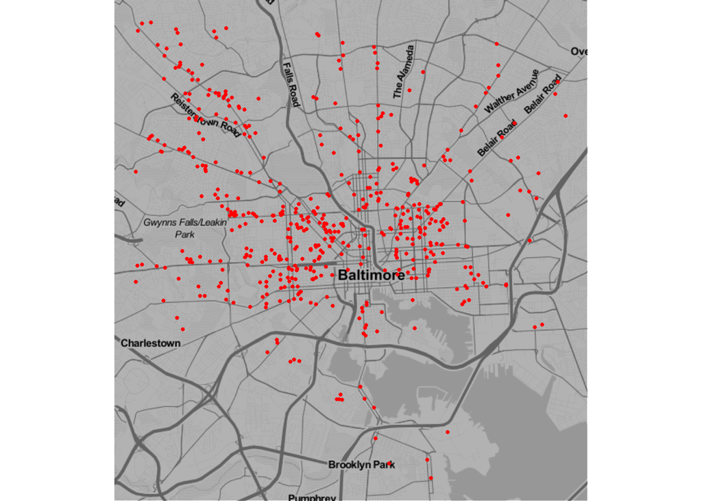